# WHAS: Example analysis for Homework 6-8

Emily Wu

2023-11-13

# Setting up

```r
# Load packages
library(survival)
library(tidyverse)
library(gtsummary)
library(labelled)
library(survminer)

# Load data
load("whas500.Rdata")

whas500 <- whas500 |>
  mutate(lenfol = lenfol/365.25)
```

These are the variables in our dataset.

```r
names(whas500)
```

```
##  [1] "id"        "age"       "gender"    "hr"        "sysbp"     "diasbp"
##  [7] "bmi"       "cvd"       "afb"       "sho"       "chf"       "av3"
## [13] "miord"     "mitype"    "year"      "admitdate" "disdate"   "fdate"
## [19] "los"       "dstat"     "lenfol"    "fstat"
```

Our outcome variables are `lenfol` (time) and `fstat` (event indicator). Some variables are just bookkeeping variables (e.g. `id, year, admitdate, disdate, fdate, los, dstat`).

Therefore we’ll focus on the covariates below in our model building proccedure.

```r
covars <- c("age", "gender", "hr", "sysbp", "diasbp", "bmi", "cvd", "afb", "sho", "chf", "av3", "miord", "mitype")
```

I also add some variable and value labels from the .txt file to make the variable names/values more meaningful.

```r
# Read in variable labels
codebook <- read_fwf("whas500_short.txt", skip = 10, col_select = 1:2) |>
  rename(Variable = X1, Description = X2)

# Add variable labels to dataset
labels <- as.list(paste0(codebook$Variable, "- ", codebook$Description))
names(labels) <- codebook$Variable
var_label(whas500) <- labels

# Add value labels
val_labels(whas500) <- list(
  gender = c(Male = 0, Female = 1),
  cvd = c(No = 0, Yes = 1),
  afb = c(No = 0, Yes = 1),
  sho = c(No = 0, Yes = 1),
  chf = c(No = 0, Yes = 1),
  av3 = c(No = 0, Yes = 1),
  miord = c(First = 0, Recurrent = 1),
  mitype = c("non Q-wave" =  0, "Q-wave" = 1)
)
```

# 0. Descriptive statistics

Before we dive into the model building procedure, it’s helpful to get some simple descriptive statistics of our covariates. You can do this any way you like. I will use tbl_summary() from the gtsummary pacage (See https://www.danieldsjoberg.com/gtsummary/articles/tbl_summary.html).

```r
tbl_summary(data = whas500 |> to_factor(),
            include = all_of(covars),
            type = all_dichotomous()~ "categorical")
```

| **Characteristic** | **N = 500**<sup>1</sup> |
| --- | --- |
| age- Age at Hospital Admission | 72 (59, 82) |
| gender- Gender |  |
| Male | 300 (60%) |
| Female | 200 (40%) |
| hr- Heart Rate | 85 (69, 100) |
| sysbp- Systolic Blood Pressure | 142 (123, 164) |
| diasbp- Diastolic Blood Pressure | 79 (63, 91) |
| bmi- Body Mass Index | 25.9 (23.2, 29.4) |
| cvd- History of CVD |  |
| No | 125 (25%) |
| Yes | 375 (75%) |
| afb- Atrial Fibrillation |  |
| No | 422 (84%) |
| Yes | 78 (16%) |
| sho- Cardiogenic Shock |  |
| No | 478 (96%) |
| Yes | 22 (4.4%) |
| chf- Congestive Heart Complications |  |
| No | 345 (69%) |
| Yes | 155 (31%) |
| av3- Complete Heart Block |  |
| No | 489 (98%) |
| Yes | 11 (2.2%) |
| miord- MI Order |  |
| First | 329 (66%) |
| Recurrent | 171 (34%) |
| mitype- MI Type |  |
| non Q-wave | 347 (69%) |
| Q-wave | 153 (31%) |

<sup>1</sup> Median (IQR); n (%)

We can also make histograms for our continuous variables.

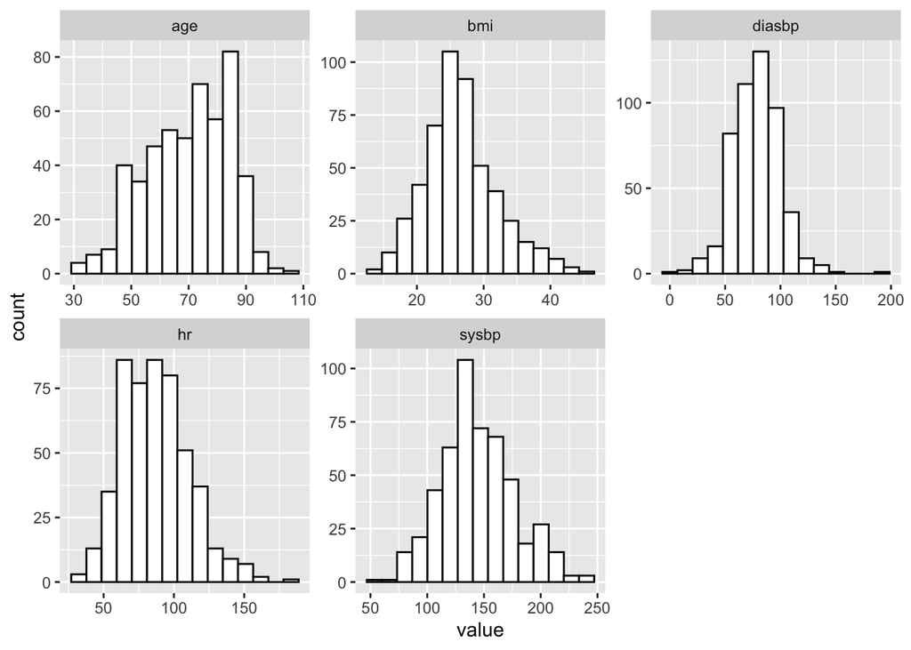

```r
continuous <- c("age", "hr", "sysbp", "diasbp", "bmi")
whas500 |>
  pivot_longer(all_of(continuous), names_to = "variable") |>
  ggplot(aes(x = value)) +
  geom_histogram(fill = "white", color = "black", bins = 15) +
  facet_wrap(~variable, scales = "free")
```

# 1. Fit univariable models for all covariates

I’ll do this using tbl_uvregression() from the gtsummary package (See https://www.danieldsjoberg.com/gtsummary/articles/tbl_regression.html#tbl_uvregression). This gives the results from fitting a univariable Cox model with each covariate.

#### Table 1

```r
tbl_uvregression(data = whas500,
                 method = survival::coxph,
                 y = Surv(lenfol, fstat),
                 include = all_of(covars),
                 exponentiate = TRUE,
                 pvalue_fun = function(x) style_pvalue(x, digits = 3))
```

| **Characteristic** | **N** | **HR**<sup>1</sup> | **95% CI**<sup>1</sup> | **p-value** |
| --- | --- | --- | --- | --- |
| age- Age at Hospital Admission | 500 | 1.07 | 1.06, 1.08 | <0.001 |
| gender- Gender | 500 | 1.46 | 1.12, 1.92 | 0.006 |
| hr- Heart Rate | 500 | 1.02 | 1.01, 1.02 | <0.001 |
| sysbp- Systolic Blood Pressure | 500 | 1.00 | 0.99, 1.00 | 0.042 |
| diasbp- Diastolic Blood Pressure | 500 | 0.98 | 0.98, 0.99 | <0.001 |
| bmi- Body Mass Index | 500 | 0.91 | 0.88, 0.93 | <0.001 |
| cvd- History of CVD | 500 | 1.33 | 0.95, 1.84 | 0.092 |
| afb- Atrial Fibrillation | 500 | 1.72 | 1.24, 2.37 | 0.001 |
| sho- Cardiogenic Shock | 500 | 3.29 | 1.99, 5.43 | <0.001 |
| chf- Congestive Heart Complications | 500 | 3.32 | 2.53, 4.35 | <0.001 |
| av3- Complete Heart Block | 500 | 1.61 | 0.75, 3.47 | 0.219 |
| miord- MI Order | 500 | 1.53 | 1.17, 2.01 | 0.002 |
| mitype- MI Type | 500 | 0.52 | 0.37, 0.72 | <0.001 |

<sup>1</sup> HR = Hazard Ratio, CI = Confidence Interval

You could also write some functions to do this yourself. e.g. Click `show`

```r
#fit Cox model with a single covariate
fit_univar <- function(covar){
  form <- paste0("Surv(lenfol, fstat) ~ ", covar)
  fit <- coxph(as.formula(form), data = whas500)
  as.data.frame(coef(summary(fit))) # could also use broom::tidy(fit) here
}

#loop through each covariate of interest and fit Cox model
univar_results <- bind_rows(lapply(covars, fit_univar)) |>
  rownames_to_column("variable")
```

In the Table 1, we see that all variables except `av3` (Complete Heart Block) are significant at the 20% significance level and therefore are candidates for the multivariable model.

Looking back at the descriptives, we also note that only 11/500 people had `av3` (complete heart block) and 22/500 people had `sho` (cardiogenic shock). If we look at the Kaplan-Meier estimates and plots, we see that after the first several months, there is little data available to use to estimate the covariate effects. Therefore, I will drop both `av3` and `sho` from consideration.

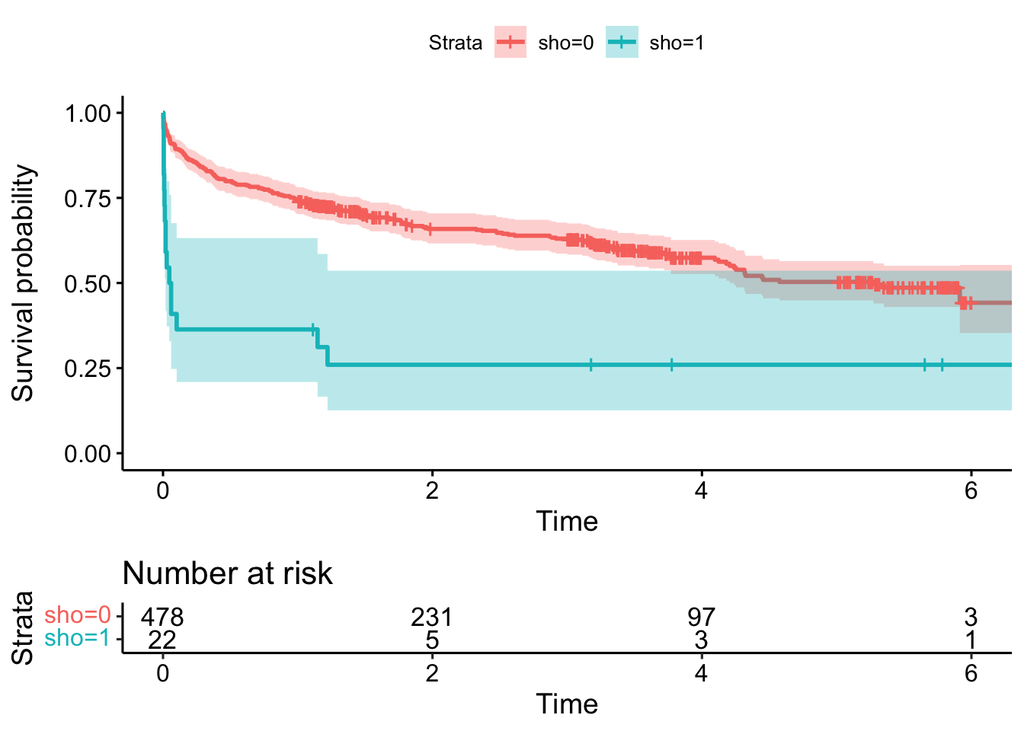

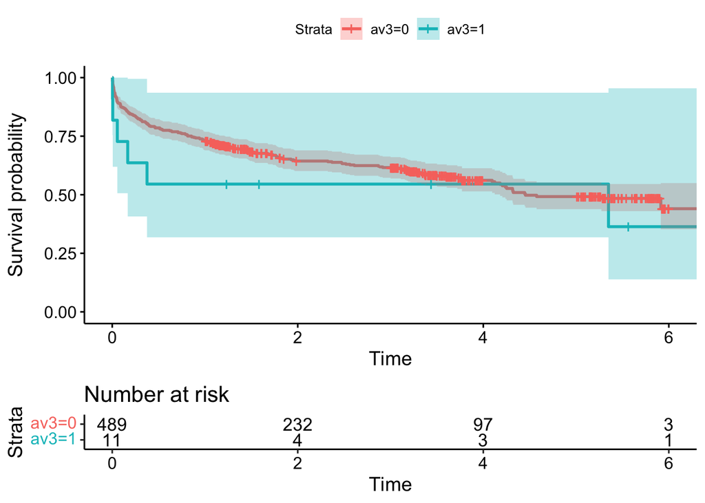

```r
ggsurvplot(survfit(Surv(lenfol, fstat) ~ sho, data = whas500),
           conf.int = TRUE,
           risk.table = TRUE)

ggsurvplot(survfit(Surv(lenfol, fstat) ~ av3, data = whas500),
           conf.int = TRUE,
           risk.table = TRUE)
```

# 2. Fit the multivariable model (usings variables vetted from step 1)

```r
fit.step2 <- coxph(Surv(lenfol, fstat) ~ age + gender + hr + sysbp + diasbp + bmi + cvd + afb + chf + miord + mitype,
                   data = whas500)
```

Below is an equivalent way if you have many/long variable names or are bad at typing…

```r
#drop variables not significant in #1
multivar <- covars[!covars %in% c("av3", "sho")]
#new formula
multivar_form <- paste0("Surv(lenfol, fstat) ~ ", paste(multivar, collapse = " + "))
fit.step2 <- coxph(as.formula(multivar_form), data = whas500)
```

I’ll display the results using tbl_regression() from gtsummary.

#### Table 2

```r
 tbl_regression(fit.step2,
                exponentiate = TRUE,
                pvalue_fun = function(x) style_pvalue(x, digits = 3))
```

| **Characteristic** | **HR**<sup>1</sup> | **95% CI**<sup>1</sup> | **p-value** |
| --- | --- | --- | --- |
| age- Age at Hospital Admission | 1.05 | 1.04, 1.06 | <0.001 |
| gender- Gender | 0.76 | 0.57, 1.01 | 0.062 |
| hr- Heart Rate | 1.01 | 1.00, 1.02 | <0.001 |
| sysbp- Systolic Blood Pressure | 1.00 | 0.99, 1.01 | 0.912 |
| diasbp- Diastolic Blood Pressure | 0.99 | 0.98, 1.00 | 0.031 |
| bmi- Body Mass Index | 0.96 | 0.93, 0.99 | 0.008 |
| cvd- History of CVD | 1.01 | 0.71, 1.43 | 0.965 |
| afb- Atrial Fibrillation | 1.14 | 0.81, 1.59 | 0.452 |
| chf- Congestive Heart Complications | 2.17 | 1.62, 2.91 | <0.001 |
| miord- MI Order | 1.04 | 0.78, 1.40 | 0.769 |
| mitype- MI Type | 0.85 | 0.59, 1.23 | 0.387 |

<sup>1</sup> HR = Hazard Ratio, CI = Confidence Interval

# 3. Remove covariates with large p-values from the model

We remove insignficant variable and check if the removal produces an “important” change (~20 % difference) in the remaining coefficients.

From Table 2, `cvd` (History of CVD) and `sysbp` (Systolic blood pressure) have the largest p-values at 0.965 and 0.912 respectively, so I’ll try to drop those.

```r
fit.step3_1 <- update(fit.step2, .~. -cvd -sysbp)
```

#### Table 3.1

```r
 tbl_regression(fit.step3_1,
                exponentiate = TRUE,
                pvalue_fun = function(x) style_pvalue(x, digits = 3))
```

| **Characteristic** | **HR**<sup>1</sup> | **95% CI**<sup>1</sup> | **p-value** |
| --- | --- | --- | --- |
| age- Age at Hospital Admission | 1.05 | 1.04, 1.06 | <0.001 |
| gender- Gender | 0.76 | 0.57, 1.01 | 0.062 |
| hr- Heart Rate | 1.01 | 1.00, 1.02 | <0.001 |
| diasbp- Diastolic Blood Pressure | 0.99 | 0.98, 1.00 | 0.004 |
| bmi- Body Mass Index | 0.96 | 0.93, 0.99 | 0.007 |
| afb- Atrial Fibrillation | 1.13 | 0.81, 1.58 | 0.456 |
| chf- Congestive Heart Complications | 2.18 | 1.63, 2.91 | <0.001 |
| miord- MI Order | 1.05 | 0.79, 1.39 | 0.759 |
| mitype- MI Type | 0.85 | 0.59, 1.21 | 0.362 |

<sup>1</sup> HR = Hazard Ratio, CI = Confidence Interval

The coefficients are pretty much the same as before. The partial likelihood ratio test comparing the model with and without these two variables has a large p-value. Therefore, we can go ahead and drop these variable.

```r
anova(fit.step3_1, fit.step2)
```

```
## Analysis of Deviance Table
##  Cox model: response is  Surv(lenfol, fstat)
##  Model 1: ~ age + gender + hr + diasbp + bmi + afb + chf + miord + mitype
##  Model 2: ~ age + gender + hr + sysbp + diasbp + bmi + cvd + afb + chf + miord + mitype
##    loglik  Chisq Df Pr(>|Chi|)
## 1 -1122.7
## 2 -1122.7 0.0154  2     0.9923
```

Now `miord` (MI Order) has the largest p-value at 0.759 and the next largest p-values are quite a bit smaller so we will try to drop only `miord`

```r
fit.step3_2 <- update(fit.step3_1, .~. -miord)
```

#### Table 3.2

```r
 tbl_regression(fit.step3_2,
                exponentiate = TRUE,
                pvalue_fun = function(x) style_pvalue(x, digits = 3))
```

| **Characteristic** | **HR**<sup>1</sup> | **95% CI**<sup>1</sup> | **p-value** |
| --- | --- | --- | --- |
| age- Age at Hospital Admission | 1.05 | 1.04, 1.06 | <0.001 |
| gender- Gender | 0.76 | 0.57, 1.01 | 0.055 |
| hr- Heart Rate | 1.01 | 1.00, 1.02 | <0.001 |
| diasbp- Diastolic Blood Pressure | 0.99 | 0.98, 1.00 | 0.004 |
| bmi- Body Mass Index | 0.96 | 0.93, 0.99 | 0.007 |
| afb- Atrial Fibrillation | 1.13 | 0.81, 1.58 | 0.460 |
| chf- Congestive Heart Complications | 2.18 | 1.63, 2.92 | <0.001 |
| mitype- MI Type | 0.84 | 0.59, 1.19 | 0.314 |

<sup>1</sup> HR = Hazard Ratio, CI = Confidence Interval

```r
fit.step3_3 <- update(fit.step3_2, .~. -afb - mitype)
```

#### Table 3.3

```r
 tbl_regression(fit.step3_3,
                exponentiate = TRUE,
                pvalue_fun = function(x) style_pvalue(x, digits = 3))
```

| **Characteristic** | **HR**<sup>1</sup> | **95% CI**<sup>1</sup> | **p-value** |
| --- | --- | --- | --- |
| age- Age at Hospital Admission | 1.05 | 1.04, 1.06 | <0.001 |
| gender- Gender | 0.76 | 0.58, 1.01 | 0.059 |
| hr- Heart Rate | 1.01 | 1.01, 1.02 | <0.001 |
| diasbp- Diastolic Blood Pressure | 0.99 | 0.98, 1.00 | 0.003 |
| bmi- Body Mass Index | 0.96 | 0.93, 0.99 | 0.005 |
| chf- Congestive Heart Complications | 2.18 | 1.64, 2.91 | <0.001 |

<sup>1</sup> HR = Hazard Ratio, CI = Confidence Interval

The partial likelihood ratio test is not significant (p = 0.48) so we can also drop these.

```r
anova(fit.step3_3, fit.step3_2)
```

```
## Analysis of Deviance Table
##  Cox model: response is  Surv(lenfol, fstat)
##  Model 1: ~ age + gender + hr + diasbp + bmi + chf
##  Model 2: ~ age + gender + hr + diasbp + bmi + afb + chf + mitype
##    loglik  Chisq Df Pr(>|Chi|)
## 1 -1123.5
## 2 -1122.7 1.4855  2     0.4758
```

Now all remaining variable are close to significant at the 5% significance level so there are no more variables to drop.

# 4. Add variables initially excluded from the multivariable model.

We only excluded `av3` and `sho` from the initial multivariable model due to concerns about data sparsity. We’ll run into this issue again if we try to add them so we can skip this step.

```r
fit.step4 <- fit.step3_3
```

# 5. Check the scale of the continuous covariates

One way to check the scale of the continuous covariates is to plot the martingale residuals from the null or tentative model against the covariate values. These plots can suggest an appropriate functional form for the continuous covariates.

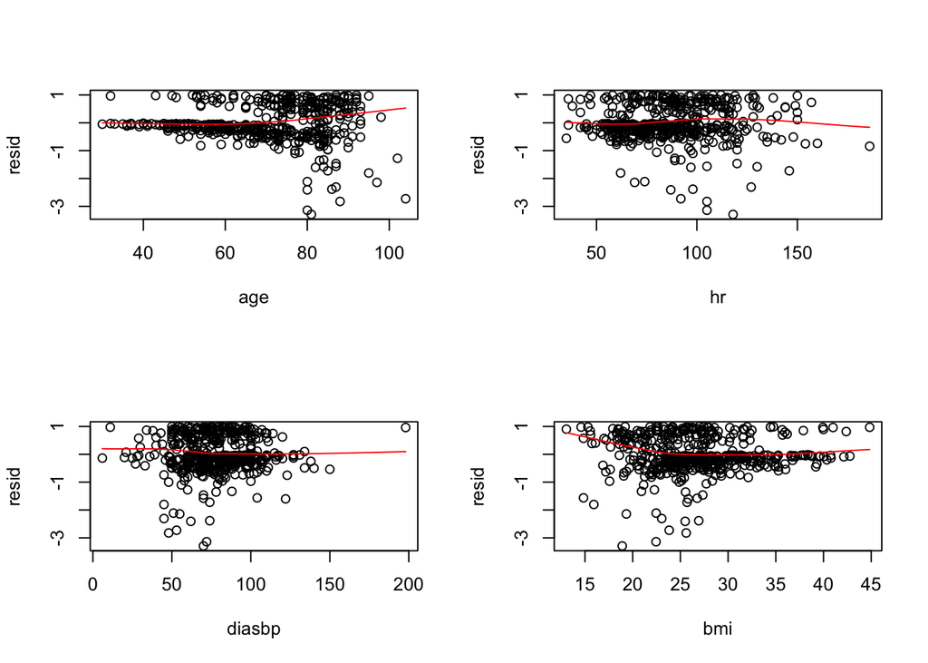

```r
#get martingale residuals
resid <- residuals(fit.step4, type = "martingale")

#scatter plot with loess smoothed line
continuous_vars <- c("age", "hr", "diasbp", "bmi")
par(mfrow = c(2,2))
for(var in continuous_vars){scatter.smooth(whas500[,var], resid, xlab = var, lpars = list(col = "red"))}
```

The martingale residual plots for `hr` and `diasbp` look pretty good. There might be some room for improvement with `age` and `bmi`. We could try adding quadratic effects `age^2` or `bmi^2` (or some other transformation) to see if that improves the fit. For simplicity, I will keep them as linear terms for this exercise. We finally have our main effects model.

```r
fit.main <- fit.step4
```

# 6. Add interactions

Below I only consider interaction terms involving `age` and any term in the main effects model, or `gender`and any term in the main effects model.

```r
main_vars <- names(fit.main$coefficients)

# add interactions one at a time
update(fit.main, .~. + age:gender, data = whas500)    #p = 0.008
update(fit.main, .~. + age:hr, data = whas500)        #p = 0.116
update(fit.main, .~. + age:sysbp, data = whas500)     #p = 0.871
update(fit.main, .~. + age:diasbp, data = whas500)    #p = 0.066
update(fit.main, .~. + age:bmi, data = whas500)       #p = 0.618
update(fit.main, .~. + age:chf, data = whas500)       #p = 0.017

update(fit.main, .~. + gender:hr, data = whas500)     #p = 0.151
update(fit.main, .~. + gender:sysbp, data = whas500)  #p = 0.245
update(fit.main, .~. + gender:diasbp, data = whas500) #p = 0.044
update(fit.main, .~. + gender:bmi, data = whas500)    #p = 0.92
update(fit.main, .~. + gender:chf, data = whas500)    #p = 0.334
```

Based on these results, I will try to add `age:gender, age:cf, gender:diasbp` (significant at the 5% level) to the main model

```r
fit.step6_1 <- update(fit.main, .~. + age:gender + age:chf + gender:diasbp, data = whas500)
```

#### Table 6.1

```r
 tbl_regression(fit.step6_1,
                exponentiate = TRUE,
                pvalue_fun = function(x) style_pvalue(x, digits = 3))
```

| **Characteristic** | **HR**<sup>1</sup> | **95% CI**<sup>1</sup> | **p-value** |
| --- | --- | --- | --- |
| age- Age at Hospital Admission | 1.07 | 1.05, 1.09 | <0.001 |
| gender- Gender | 2.42 | 0.19, 30.7 | 0.496 |
| hr- Heart Rate | 1.01 | 1.01, 1.02 | <0.001 |
| diasbp- Diastolic Blood Pressure | 0.99 | 0.98, 0.99 | <0.001 |
| bmi- Body Mass Index | 0.96 | 0.93, 0.99 | 0.015 |
| chf- Congestive Heart Complications | 11.8 | 1.63, 85.0 | 0.015 |
| age- Age at Hospital Admission * gender- Gender | 0.98 | 0.95, 1.00 | 0.092 |
| age- Age at Hospital Admission * chf- Congestive Heart Complications | 0.98 | 0.95, 1.00 | 0.093 |
| gender- Gender * diasbp- Diastolic Blood Pressure | 1.01 | 1.0, 1.02 | 0.231 |

<sup>1</sup> HR = Hazard Ratio, CI = Confidence Interval

Now none of the interactions are significant. We remove the `gender:diasbp` first.

```r
fit.step6_2 <- update(fit.step6_1, .~. - gender:diasbp, data = whas500)
```

#### Table 6.2

```r
 tbl_regression(fit.step6_2,
                exponentiate = TRUE,
                pvalue_fun = function(x) style_pvalue(x, digits = 3))
```

| **Characteristic** | **HR**<sup>1</sup> | **95% CI**<sup>1</sup> | **p-value** |
| --- | --- | --- | --- |
| age- Age at Hospital Admission | 1.07 | 1.05, 1.10 | <0.001 |
| gender- Gender | 6.30 | 0.86, 46.1 | 0.070 |
| hr- Heart Rate | 1.01 | 1.01, 1.02 | <0.001 |
| diasbp- Diastolic Blood Pressure | 0.99 | 0.98, 1.00 | <0.001 |
| bmi- Body Mass Index | 0.96 | 0.93, 0.99 | 0.012 |
| chf- Congestive Heart Complications | 12.5 | 1.73, 90.0 | 0.012 |
| age- Age at Hospital Admission * gender- Gender | 0.97 | 0.95, 1.00 | 0.036 |
| age- Age at Hospital Admission * chf- Congestive Heart Complications | 0.98 | 0.95, 1.00 | 0.080 |

<sup>1</sup> HR = Hazard Ratio, CI = Confidence Interval

We now remove `age:chf`

```r
fit.step6_3 <- update(fit.step6_2, .~. - age:chf, data = whas500)
```

#### Table 6.3

```r
 tbl_regression(fit.step6_3,
                exponentiate = TRUE,
                pvalue_fun = function(x) style_pvalue(x, digits = 3))
```

| **Characteristic** | **HR**<sup>1</sup> | **95% CI**<sup>1</sup> | **p-value** |
| --- | --- | --- | --- |
| age- Age at Hospital Admission | 1.06 | 1.05, 1.08 | <0.001 |
| gender- Gender | 9.55 | 1.45, 62.8 | 0.019 |
| hr- Heart Rate | 1.01 | 1.01, 1.02 | <0.001 |
| diasbp- Diastolic Blood Pressure | 0.99 | 0.98, 1.00 | 0.002 |
| bmi- Body Mass Index | 0.96 | 0.93, 0.99 | 0.006 |
| chf- Congestive Heart Complications | 2.18 | 1.64, 2.90 | <0.001 |
| age- Age at Hospital Admission * gender- Gender | 0.97 | 0.95, 0.99 | 0.008 |

<sup>1</sup> HR = Hazard Ratio, CI = Confidence Interval

We’ll take this as our final model.

```r
fit.final <- fit.step6_3
```

# 7. Diagnostics: check overall goodness of fit and proportioonal hazards assumption

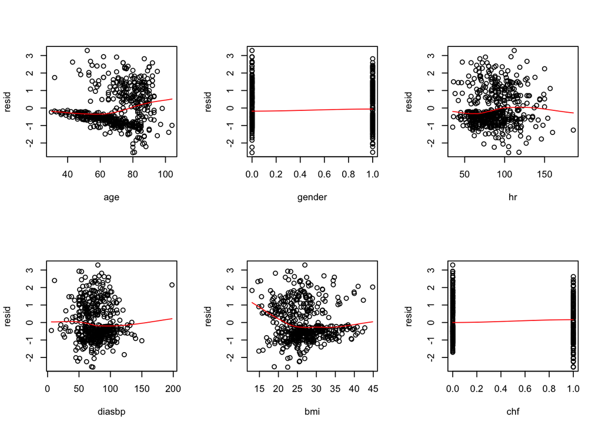

```r
resid <- residuals(fit.final, type = "deviance")
final_vars <- names(coef(fit.final))

par(mfrow = c(2,3))
for(var in final_vars[1:6]){scatter.smooth(whas500[,var], resid, xlab = var, lpars = list(col = "red"))}
```

The deviance residuals look mostly centered around 0. The residuals with BMI show a slight curvilinear relationship so we might consider allowing BMI to have a non-linear relationship with the log-hazards if that is clinically reasonable and meaningful.

```r
schoen <- cox.zph(fit.final)
schoen
```

```
##               chisq df    p
## age        1.009056  1 0.32
## gender     0.000631  1 0.98
## hr         1.085696  1 0.30
## diasbp     0.213622  1 0.64
## bmi        1.224592  1 0.27
## chf        0.183055  1 0.67
## age:gender 0.007637  1 0.93
## GLOBAL     6.381490  7 0.50
```

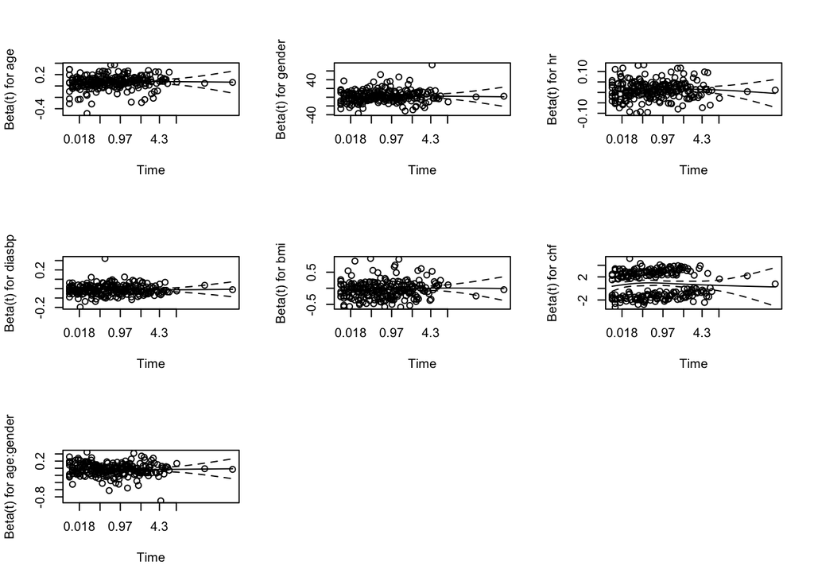

```r
par(mfrow = c(3,3))
plot(schoen)
```

Since the smoothed scaled Shoenfield residuals follow a mostly horizontal line, the proportional hazards assumption appears to be reasonable.